# ml4077

# Step 0

```r
#packages.used=c("rvest", "tibble", "qdap",
#                "sentimentr", "gplots", "dplyr",
#                "tm", "syuzhet"need., "factoextra",
#                "beeswarm", "scales", "RColorBrewer",
#                "RANN", "tm", "topicmodels","tydytext","wordcloud")

# check packages that need to be installed.
#packages.needed=setdiff(packages.used,
#                        intersect(installed.packages()[,1],
#                                  packages.used))
# install additional packages
#if(length(packages.needed)>0){
#  install.packages(packages.needed, dependencies = TRUE)
#}

# load packages
library("rvest")
library("tibble")
library("qdap")
library("sentimentr")
library("gplots")
library("dplyr")
library("tm")
library("syuzhet")
library("factoextra")
library("beeswarm")
library("scales")
library("RColorBrewer")
library("RANN")
library("tm")
library("topicmodels")
library('stringr')
library('wordcloud')
library('SnowballC')
library('text2vec')
library('wordcloud')
library('tidytext')
library('ggplot2')
library('scales') # visualisation

source("../lib/plotstacked.R")
source("../lib/speechFuncs.R")
```

# Step 1

I scraped the inaugaural speech part from the website and integrated them with the inauglist. Finally, I got the speech.list dataframe, which summaries the information of inaugural speeches for each president, inculding their sentences as well as the emotion of each sentence.

```r
### Inauguaral speeches
main.page <- read_html(x = "http://www.presidency.ucsb.edu/inaugurals.php")
# Get link URLs
# f.speechlinks is a function for extracting links from the list of speeches.
inaug=f.speechlinks(main.page)
#head(inaug)
#as.Date(inaug[,1],"%m %d, %y")
inaug=inaug[-nrow(inaug),] # remove the last line, irrelevant due to error.

inaug.list=read.csv("../data/inauglist.csv", stringsAsFactors = FALSE)
speech.list=cbind(inaug.list, inaug)
names(speech.list)[1] <- "President"
```

# Step 2

Cleaning the data and counting the number of words in each sentences. Finally, I created speech.list and sentence.list which record the president and speeches and sentences.

```r
# Loop over each row in speech.list
speech.list$fulltext=NA
for(i in seq(nrow(speech.list))) {
  text <- read_html(speech.list$urls[i]) %>% # load the page
    html_nodes(".displaytext") %>%
    html_text() # get the text
  speech.list$fulltext[i]=text
  # Create the file name
  filename <- paste0("../data/fulltext/",
                     speech.list$type[i],
                     speech.list$File[i], "-",
                     speech.list$Term[i], ".txt")
  sink(file = filename) %>% # open file to write
  cat(text)  # write the file
  sink() # close the file
}
sentence.list=NULL
for(i in 1:nrow(speech.list)){
  sentences=sent_detect(speech.list$fulltext[i],
                        endmarks = c("?", ".", "!", "|",";"))
  if(length(sentences)>0){
    emotions=get_nrc_sentiment(sentences)
    word.count=word_count(sentences)
    # colnames(emotions)=paste0("emo.", colnames(emotions))
    # in case the word counts are zeros?
    emotions=diag(1/(word.count+0.01))%*%as.matrix(emotions)
    sentence.list=rbind(sentence.list,
                        cbind(speech.list[i,-ncol(speech.list)],
                              sentences=as.character(sentences),
                              word.count,
                              emotions,
                              sent.id=1:length(sentences)
                              )
    )
  }
}
sentence.list=
  sentence.list%>%
  filter(!is.na(word.count))
sentence.list$type="Inaug"
```

# Step 3 Analyzing how events affect the emotions of inaugural speeches

It deserves to be mention that at the beginning emotion anger is higher than in the end, especially of the wars.

```r
par(mfrow=c(4,1), mar=c(1,0,2,0), bty="n", xaxt="n", yaxt="n", font.main=1)
speech.df=tbl_df(sentence.list)%>%filter(File=="GeorgeWashington", type=="Inaug",Term==1)%>%select(sent.id, anger:trust)
speech.df=as.matrix(speech.df)
speech.df[,-1]=replace(speech.df[,-1], speech.df[,-1]<1/15, 0.001)
speech.df[,-1]=f.smooth.topic(x=speech.df[,1], y=speech.df[,-1])
plot.stacked(speech.df[,1], speech.df[,2:9],
             xlab="Sentences", ylab="sentiment share", main="George Washington(Funding), Inaugrual")
```

```
## [1] 0.009558031 0.019116062 0.028674094 0.038232125 0.047790156 0.057348187
## [7] 0.066906218 0.076464250
```

```r
speech.df=tbl_df(sentence.list)%>%filter(File=="GeorgeWashington", type=="Inaug",Term==2)%>%select(sent.id, anger:trust)
speech.df=as.matrix(speech.df)
speech.df[,-1]=replace(speech.df[,-1], speech.df[,-1]<1/15, 0.001)
speech.df[,-1]=f.smooth.topic(x=speech.df[,1], y=speech.df[,-1])
plot.stacked(speech.df[,1], speech.df[,2:9],
             xlab="Sentences", ylab="sentiment share", main="George Washington(Normal), Inaugrual")
```

```
## [1] 0.01808976 0.03617951 0.05426927 0.07235903 0.09044879 0.10853854
## [7] 0.12662830 0.14471806
```

```r
speech.df=tbl_df(sentence.list)%>%filter(File=="AbrahamLincoln", type=="Inaug",Term==1)%>%select(sent.id, anger:trust)
speech.df=as.matrix(speech.df)
speech.df[,-1]=replace(speech.df[,-1], speech.df[,-1]<1/15, 0.001)
speech.df[,-1]=f.smooth.topic(x=speech.df[,1], y=speech.df[,-1])
plot.stacked(speech.df[,1], speech.df[,2:9],
             xlab="Sentences", ylab="sentiment share", main="Abraham Lincoln(The beginning of Civil War), Inaugrual")
```

```
## [1] 0.01912806 0.03825613 0.05738419 0.07651225 0.09564032 0.11476838
## [7] 0.13389644 0.15302451
```

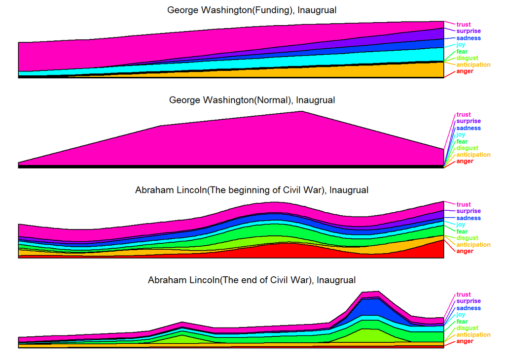

```
## [1] 0.04625838 0.09251676 0.13877515 0.18503353 0.23129191 0.27755029
## [7] 0.32380868 0.37006706
```

```r
speech.df=tbl_df(sentence.list)%>%filter(File=="AbrahamLincoln", type=="Inaug",Term==2)%>%select(sent.id, anger:trust)
speech.df=as.matrix(speech.df)
speech.df[,-1]=replace(speech.df[,-1], speech.df[,-1]<1/15, 0.001)
speech.df[,-1]=f.smooth.topic(x=speech.df[,1], y=speech.df[,-1])
plot.stacked(speech.df[,1], speech.df[,2:9],
             xlab="Sentences", ylab="sentiment share", main="Abraham Lincoln(The end of Civil War), Inaugrual")
```

```r
speech.df=tbl_df(sentence.list)%>%filter(File=="WoodrowWilson", type=="Inaug",Term==1)%>%select(sent.id, anger:trust)
speech.df=as.matrix(speech.df)
speech.df[,-1]=replace(speech.df[,-1], speech.df[,-1]<1/15, 0.001)
speech.df[,-1]=f.smooth.topic(x=speech.df[,1], y=speech.df[,-1])
plot.stacked(speech.df[,1], speech.df[,2:9],
             xlab="Sentences", ylab="sentiment share", main="Woodrow Wilson (The beginning of World WarI), Inaugrual")#第一次世界大战
```

```
## [1] 0.01915028 0.03830056 0.05745084 0.07660111 0.09575139 0.11490167
## [7] 0.13405195 0.15320223
```

```r
speech.df=tbl_df(sentence.list)%>%filter(File=="WoodrowWilson", type=="Inaug",Term==2)%>%select(sent.id, anger:trust)
speech.df=as.matrix(speech.df)
speech.df[,-1]=replace(speech.df[,-1], speech.df[,-1]<1/15, 0.001)
speech.df[,-1]=f.smooth.topic(x=speech.df[,1], y=speech.df[,-1])
plot.stacked(speech.df[,1], speech.df[,2:9],
             xlab="Sentences", ylab="sentiment share", main="Woodrow Wilson (The end of World WarI), Inaugrual")
```

```
## [1] 0.04257538 0.08515076 0.12772614 0.17030152 0.21287689 0.25545227
## [7] 0.29802765 0.34060303
```

```r
speech.df=tbl_df(sentence.list)%>%filter(File=="HerbertHoover", type=="Inaug",Term==1)%>%select(sent.id, anger:trust)
speech.df=as.matrix(speech.df)
speech.df[,-1]=replace(speech.df[,-1], speech.df[,-1]<1/15, 0.001)
speech.df[,-1]=f.smooth.topic(x=speech.df[,1], y=speech.df[,-1])
plot.stacked(speech.df[,1], speech.df[,2:9],
             xlab="Sentences", ylab="sentiment share", main="Herbert Hoover (The beginning of Great Depression), Inaugrual")
```

```
## [1] 0.04490867 0.08981734 0.13472601 0.17963469 0.22454336 0.26945203
## [7] 0.31436070 0.35926937
```

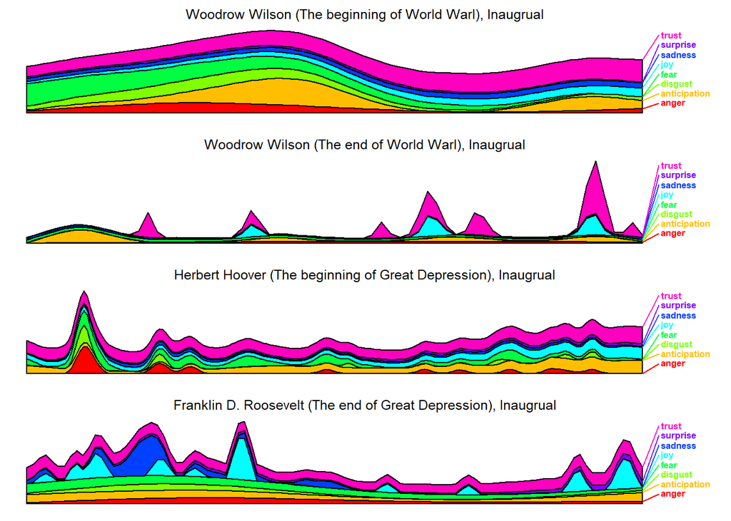

```
## [1] 0.03871327 0.07742655 0.11613982 0.15485309 0.19356637 0.23227964
## [7] 0.27099292 0.30970619
```

```r
speech.df=tbl_df(sentence.list)%>%filter(File=="FranklinDRoosevelt", type=="Inaug",Term==1)%>%select(sent.id, anger:trust)
speech.df=as.matrix(speech.df)
speech.df[,-1]=replace(speech.df[,-1], speech.df[,-1]<1/15, 0.001)
speech.df[,-1]=f.smooth.topic(x=speech.df[,1], y=speech.df[,-1])
plot.stacked(speech.df[,1], speech.df[,2:9],
             xlab="Sentences", ylab="sentiment share", main="Franklin D. Roosevelt (The end of Great Depression), Inaugrual")
```

```r
speech.df=tbl_df(sentence.list)%>%filter(File=="FranklinDRoosevelt", type=="Inaug",Term==3)%>%select(sent.id, anger:trust)
speech.df=as.matrix(speech.df)
speech.df[,-1]=replace(speech.df[,-1], speech.df[,-1]<1/15, 0.001)
speech.df[,-1]=f.smooth.topic(x=speech.df[,1], y=speech.df[,-1])
plot.stacked(speech.df[,1], speech.df[,2:9],
             xlab="Sentences", ylab="sentiment share", main="Franklin D. Roosevelt (The beginning of World WarII), Inaugrual")
```

```
## [1] 0.02415050 0.04830101 0.07245151 0.09660201 0.12075252 0.14490302
## [7] 0.16905352 0.19320403
```

```r
speech.df=tbl_df(sentence.list)%>%filter(File=="FranklinDRoosevelt", type=="Inaug",Term==4)%>%select(sent.id, anger:trust)
speech.df=as.matrix(speech.df)
speech.df[,-1]=replace(speech.df[,-1], speech.df[,-1]<1/15, 0.001)
speech.df[,-1]=f.smooth.topic(x=speech.df[,1], y=speech.df[,-1])
plot.stacked(speech.df[,1], speech.df[,2:9],
             xlab="Sentences", ylab="sentiment share", main="Franklin D. Roosevelt (The end of World WarII), Inaugrual")
```

```
## [1] 0.08813594 0.17627188 0.26440782 0.35254376 0.44067970 0.52881564
## [7] 0.61695159 0.70508753
```

```r
speech.df=tbl_df(sentence.list)%>%filter(File=="BarackObama", type=="Inaug",Term==1)%>%select(sent.id, anger:trust)
speech.df=as.matrix(speech.df)
speech.df[,-1]=replace(speech.df[,-1], speech.df[,-1]<1/15, 0.001)
speech.df[,-1]=f.smooth.topic(x=speech.df[,1], y=speech.df[,-1])
plot.stacked(speech.df[,1], speech.df[,2:9],
             xlab="Sentences", ylab="sentiment share", main="Barack Obama(The end of Economic Crisis), Inaugrual")
```

```
## [1] 0.03598329 0.07196657 0.10794986 0.14393314 0.17991643 0.21589972
## [7] 0.25188300 0.28786629
```

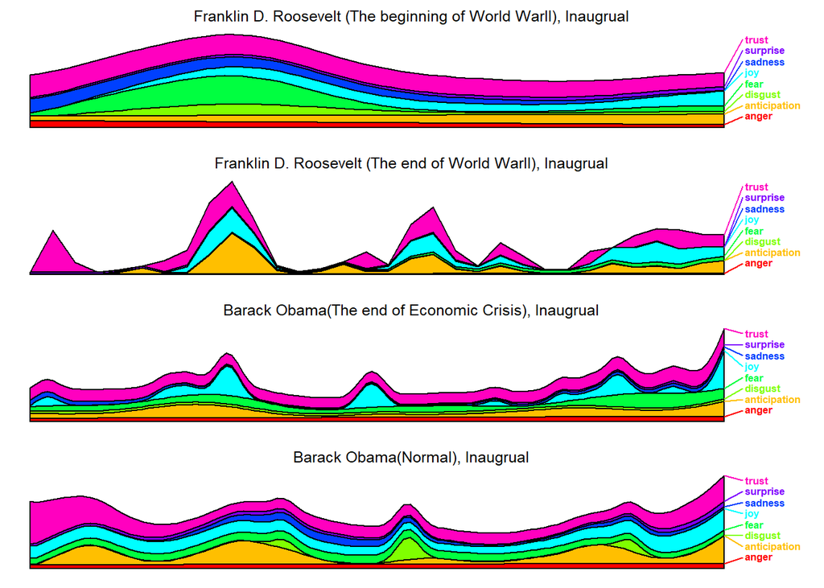

```
## [1] 0.02660774 0.05321548 0.07982322 0.10643097 0.13303871 0.15964645
## [7] 0.18625419 0.21286193
```

```r
speech.df=tbl_df(sentence.list)%>%filter(File=="BarackObama", type=="Inaug",Term==2)%>%select(sent.id, anger:trust)
speech.df=as.matrix(speech.df)
speech.df[,-1]=replace(speech.df[,-1], speech.df[,-1]<1/15, 0.001)
speech.df[,-1]=f.smooth.topic(x=speech.df[,1], y=speech.df[,-1])
plot.stacked(speech.df[,1], speech.df[,2:9],
             xlab="Sentences", ylab="sentiment share", main="Barack Obama(Normal), Inaugrual")
```

I select data according to the presidents and their terms.

```r
sel.comparison.2 <- c("GeorgeWashington","AbrahamLincoln","WoodrowWilson","HerbertHoover","FranklinDRoosevelt","BarackObama")
term.length = c(1:4)
```

Then I plot the heatmap and the comparing is more straightforward. It is not hard to see that, except Great Depression, at the beginning of these events, the negative are more than at the end. For example, at the beginning of World War I, the feeling of disgust is more than at the end of World War I.

I think the abnormal of Great Depression is due to different speech-style of different presidents(Franklin D. Roosevelt and Herbert Hoover).

```r
sentiment.summary=sentence.list%>%filter(File%in%sel.comparison.2, Term==c(1:4))%>%
              select(File,Term, positive:negative)%>%
              group_by(File,Term)%>%
              summarise_each(funs(mean))
```

```
## `summarise_each()` is deprecated.
## Use `summarise_all()`, `summarise_at()` or `summarise_if()` instead.
## To map `funs` over all variables, use `summarise_all()`
```

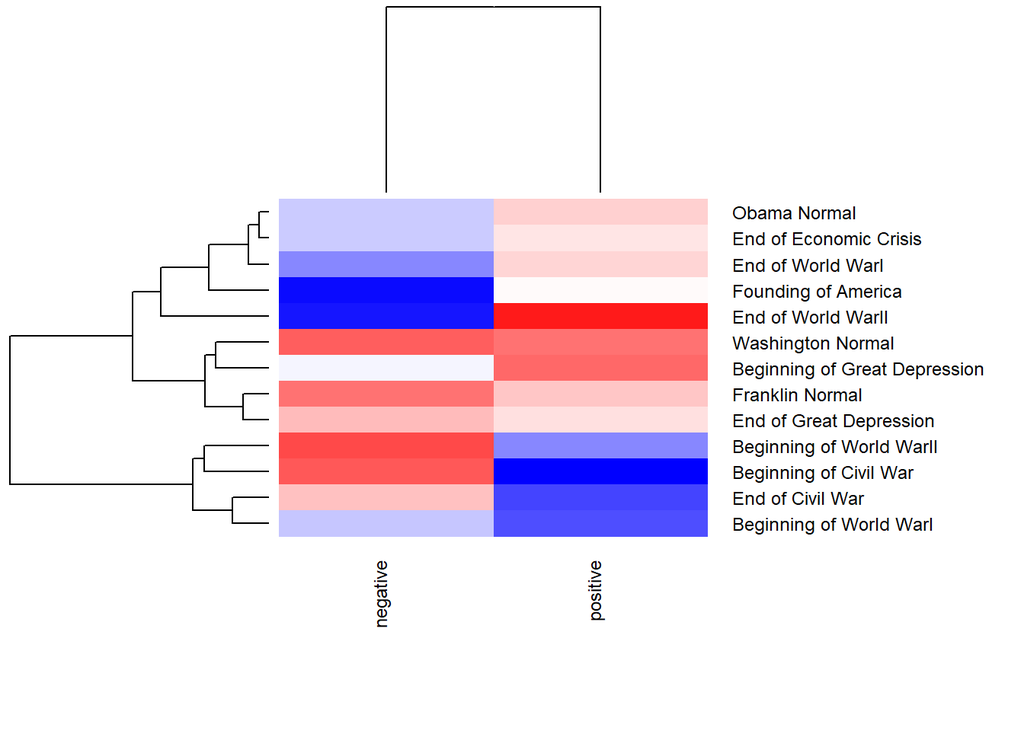

```r
sentiment.summary= as.data.frame(sentiment.summary)
rowname <- c("Beginning of Civil War","End of Civil War","End of Economic Crisis","Obama Normal","End of Great Depression", "Franklin Normal","Beginning of World WarII", "End of World WarII", "Founding of America", "Washington Normal","Beginning of Great Depression", "Beginning of World WarI","End of World WarI")
rownames(sentiment.summary) = rowname

heatmap.2(as.matrix(sentiment.summary[,c(-1,-2)]),
          scale = "column", key=F,
          col = bluered(100),
          cexRow = 0.9, cexCol = 0.9, margins = c(8, 13),
          trace = "none", density.info = "none")
```

# Step 4 Analyzing how events affect the topics of inaugural speeches

Now, I will analyze how events affect the topics of inaugural speeches and I use lda model to ensure the topic in different speeches.

```r
inaug.speech = sentence.list%>%filter(File%in%sel.comparison.2, Term==c(1:4))%>%
              select(File,Term, sentences)%>%
              group_by(File,Term)
corpus.list=sentence.list[2:(nrow(sentence.list)-1), ]
sentence.pre=sentence.list$sentences[1:(nrow(sentence.list)-2)]
sentence.post=sentence.list$sentences[3:(nrow(sentence.list)-1)]
corpus.list$snipets=paste(sentence.pre, corpus.list$sentences, sentence.post, sep=" ")
rm.rows=(1:nrow(corpus.list))[corpus.list$sent.id==1]
rm.rows=c(rm.rows, rm.rows-1)
corpus.list=corpus.list[-rm.rows, ]
docs <- Corpus(VectorSource(corpus.list$snipets))
writeLines(as.character(docs[[sample(1:nrow(corpus.list), 1)]]));
```

```
## and no other definite line can be drawn between the inestimable liberty of the press and its demoralizing licentiousness. If there be still improprieties which this rule would not restrain, its supplement must be sought in the censorship of public opinion. Contemplating the union of sentiment now…
```

```r
#remove potentially problematic symbols
docs <-tm_map(docs,content_transformer(tolower))
writeLines(as.character(docs[[sample(1:nrow(corpus.list), 1)]]));
```

```
## there is another ground for the adoption of the veto principle, which had probably more influence in recommending it to the convention than any other. i refer to the security which it gives to the just and equitable action of the legislature upon all parts of the union. it could not but have occu…
```

```r
#remove punctuation
docs <- tm_map(docs, removePunctuation);
writeLines(as.character(docs[[sample(1:nrow(corpus.list), 1)]]));
```

```
## perfection in our organization could not have been expected in the outset either in the national or state governments or in tracing the line between their respective powers but no serious conflict has arisen nor any contest but such as are managed by argument and by a fair appeal to the good sens…
```

```r
#Strip digits
docs <- tm_map(docs, removeNumbers);
writeLines(as.character(docs[[sample(1:nrow(corpus.list), 1)]]));
```

```
## action in this image and to this end is feasible under the form of government which we have inherited from our ancestors our constitution is so simple and practical that it is possible always to meet extraordinary needs by changes in emphasis and arrangement without loss of essential form that is…
```

```r
#remove stopwords
docs <- tm_map(docs, removeWords, stopwords("english"));
writeLines(as.character(docs[[sample(1:nrow(corpus.list), 1)]]));
```

```
##  shall respect  treaty commitments  shall support vigorously  principle   country   right  impose  will  rule  another  force  shall continue   era  negotiation  work   limitation  nuclear arms   reduce  danger  confrontation   great powers
```

```r
#remove whitespace
docs <- tm_map(docs, stripWhitespace);
writeLines(as.character(docs[[sample(1:nrow(corpus.list), 1)]]));
```

```
##  duty fulfilled service one another never tiring never yielding never finishing renew purpose today make country just generous affirm dignity lives every life work continues story goes angel still rides whirlwind directs storm
```

```r
#Stem document
docs <- tm_map(docs,stemDocument)
writeLines(as.character(docs[[sample(1:nrow(corpus.list), 1)]]));
```

```
## prosper power yes import must maintain let us never forget greatest progress made greatest progress yet make human heart end world wealth thousand armi match strength decenc human spirit
```

```r
dtm <- DocumentTermMatrix(docs)
#convert rownames to filenames#convert rownames to filenames
rownames(dtm) <- paste(corpus.list$type, corpus.list$File,
                       corpus.list$Term, corpus.list$sent.id, sep="_");

rowTotals <- apply(dtm , 1, sum) #Find the sum of words in each Document

dtm  <- dtm[rowTotals> 0, ]
corpus.list=corpus.list[rowTotals>0, ]

#Set parameters for Gibbs sampling
burnin <- 4000
iter <- 2000
thin <- 500
seed <-list(2003,5,63,100001,765)
nstart <- 5
best <- TRUE

#Number of topics
k <- 8

#Run LDA using Gibbs sampling
ldaOut <-LDA(dtm, k, method="Gibbs", control=list(nstart=nstart,
                                                 seed = seed, best=best,
                                                 burnin = burnin, iter = iter,
                                                 thin=thin))
#write out results
#docs to topics
ldaOut.topics <- as.matrix(topics(ldaOut));
table(c(1:k, ldaOut.topics));
```

```
##
##   1   2   3   4   5   6   7   8
## 736 660 700 612 619 708 604 900
```

```r
write.csv(ldaOut.topics,file=paste("../out/LDAGibbs",k,"DocsToTopics.csv"));

#top 6 terms in each topic
ldaOut.terms <- as.matrix(terms(ldaOut,20));
write.csv(ldaOut.terms,file=paste("../out/LDAGibbs",k,"TopicsToTerms.csv"));

#probabilities associated with each topic assignment
topicProbabilities <- as.data.frame(ldaOut@gamma);
write.csv(topicProbabilities,file=paste("../out/LDAGibbs",k,"TopicProbabilities.csv"));

terms.beta=ldaOut@beta
terms.beta=scale(terms.beta)
topics.terms=NULL
for(i in 1:k){
  topics.terms=rbind(topics.terms, ldaOut@terms[order(terms.beta[i,], decreasing = TRUE)[1:7]])
}
topics.terms;
```

```
##      [,1]        [,2]            [,3]         [,4]      [,5]
## [1,] "law"       "execut"        "congress"   "elect"   "howev"
## [2,] "confid"    "fellowcitizen" "countrymen" "devot"   "difficulti"
## [3,] "necessari" "industri"      "revenu"     "busi"    "resourc"
## [4,] "object"    "feder"         "domest"     "perfect" "term"
## [5,] "treati"    "readi"         "intercours" "sincer"  "deal"
## [6,] "day"       "face"          "past"       "word"    "oath"
## [7,] "must"      "human"         "order"      "true"    "problem"
## [8,] "america"   "know"          "heart"      "earth"   "children"
##      [,6]       [,7]
## [1,] "depart"   "either"
## [2,] "impos"    "error"
## [3,] "trade"    "possibl"
## [4,] "none"     "sovereignti"
## [5,] "particip" "prefer"
## [6,] "father"   "greatest"
## [7,] "social"   "class"
## [8,] "ideal"    "turn"
```

```r
ldaOut.terms;
```

```
##       Topic 1     Topic 2    Topic 3     Topic 4     Topic 5    Topic 6
##  [1,] "law"       "countri"  "great"     "govern"    "will"     "time"
##  [2,] "upon"      "duti"     "war"       "state"     "nation"   "now"
##  [3,] "shall"     "may"      "interest"  "power"     "peac"     "one"
##  [4,] "execut"    "everi"    "without"   "right"     "can"      "year"
##  [5,] "congress"  "great"    "public"    "constitut" "make"     "hope"
##  [6,] "public"    "confid"   "secur"     "unit"      "never"    "day"
##  [7,] "parti"     "upon"     "forc"      "union"     "polici"   "great"
##  [8,] "question"  "much"     "necessari" "peopl"     "seek"     "first"
##  [9,] "may"       "present"  "industri"  "citizen"   "war"      "presid"
## [10,] "subject"   "interest" "increas"   "preserv"   "purpos"   "futur"
## [11,] "effect"    "shall"    "requir"    "exist"     "other"    "hand"
## [12,] "offic"     "best"     "countri"   "form"      "alway"    "histori"
## [13,] "made"      "high"     "made"      "institut"  "strength" "man"
## [14,] "legisl"    "faith"    "revenu"    "equal"     "even"     "citizen"
```

[output cut: 27 more lines]

```r
topics.hash=c("Legislation","Belief","Economy","Unity","Military","Hope","Equality","America")
corpus.list$ldatopic=as.vector(ldaOut.topics)
corpus.list$ldahash=topics.hash[ldaOut.topics]

colnames(topicProbabilities)=topics.hash
corpus.list.df=cbind(corpus.list, topicProbabilities)
```

For the Founding for America, the main topic is about “Belief” and “Legislation. It is not hard to understand because the president need his people to believe him and his country. And the most important thing for them to do at that time was to build a complete judicial system. And president Washington continued these topic to his second term, while he put more effort on giving people hope after the foundation.

For Great Depression, the president paid more attention on “Economy” at the end period than at the beginning. Although there is no inaugural speech at the beginning of economic crisis, I could still compare speech at the end period with Obama’s noraml speech. And it is not hard to see, Obama emphasized more on economy at the end of economic crisis than his normal period.

In summary, the funding of America let Washington underlined his hope for “Belief” and “Legislation”. The militray event would let president pay more attention on “Military” and “Hope” during inaugural speeches and economic events make presidents emphasize topic “Economy.”

```r
par(mar=c(1,1,1,1))
topic.summary=tbl_df(corpus.list.df)%>%
              filter(type%in%c("Inaug"), File%in%sel.comparison.2,Term==c(1:4))%>%
              select(File,Term, Legislation:America)%>%
              group_by(File,Term)%>%
              summarise_each(funs(mean))
```

```
## `summarise_each()` is deprecated.
## Use `summarise_all()`, `summarise_at()` or `summarise_if()` instead.
## To map `funs` over all variables, use `summarise_all()`
```

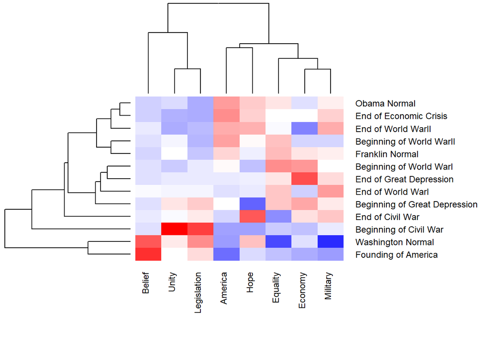

```r
topic.summary=as.data.frame(topic.summary)
rownames(topic.summary)=rowname
heatmap.2(as.matrix(topic.summary[,c(1:8)+2]),
          scale = "column", key=F,
          col = bluered(100),
          cexRow = 0.9, cexCol = 0.9, margins = c(8, 13),
          trace = "none", density.info = "none")
```

# Step 5 Inspect an overall wordcloud

I could use the wordcloud figure to see what words appear more. Here, I will take civil war and Great Depression as examples to analyze the change of topics.

At the beginning of civil war, the constitution and union and government appear more.

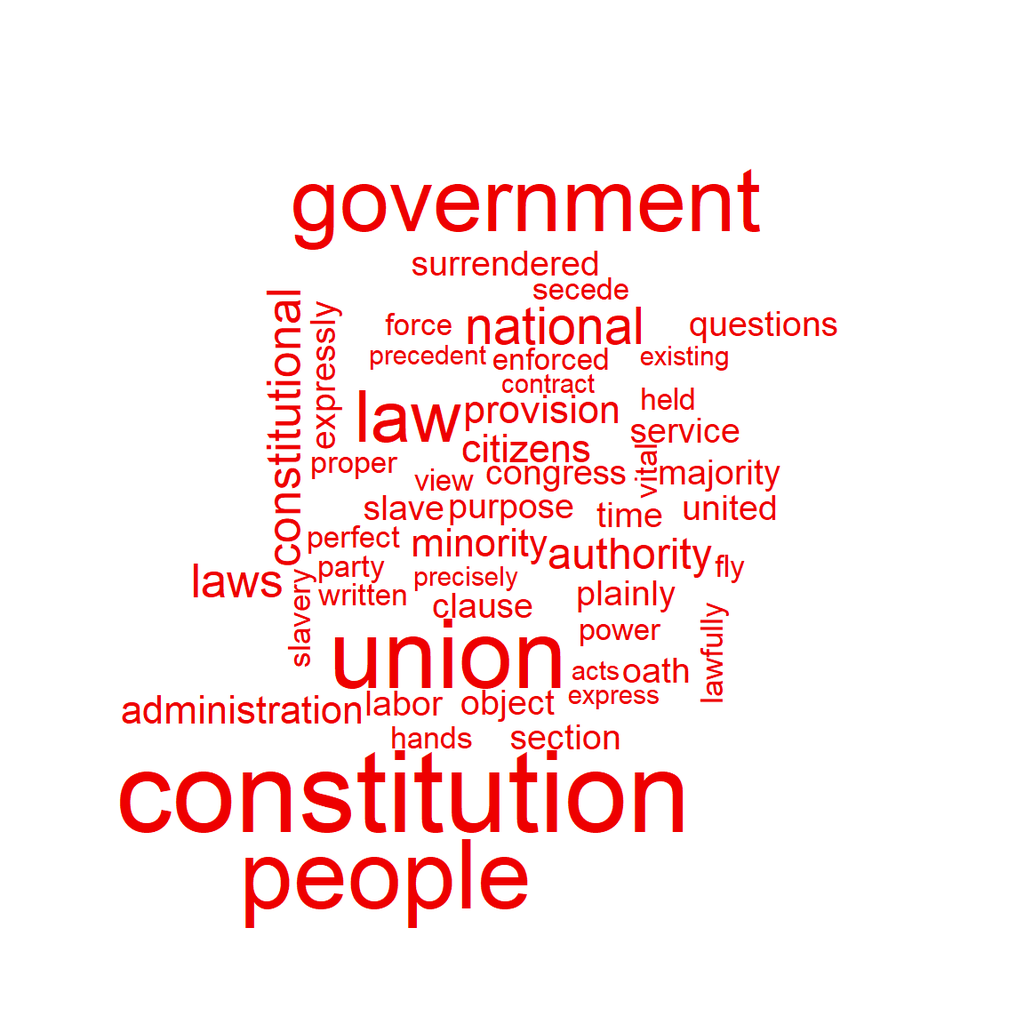

```r
wcd1 <- sentence.list %>% filter(File %in% "AbrahamLincoln", Term == 1) %>% select(File, sentences)
wcd1$sentences <- as.character(wcd1$sentences)
wcd1 <- wcd1 %>% unnest_tokens(word, sentences)
wcd1 <- wcd1 %>%
  anti_join(stop_words, by = "word")
wcd1 %>%
  count(word) %>%
  with(wordcloud(word, n, max.words = 50, color = "red2"))
```

I could use the wordcloud figure to see what words appear more. At the end of civil war, the war appears a lot which means he emphasized more on military.

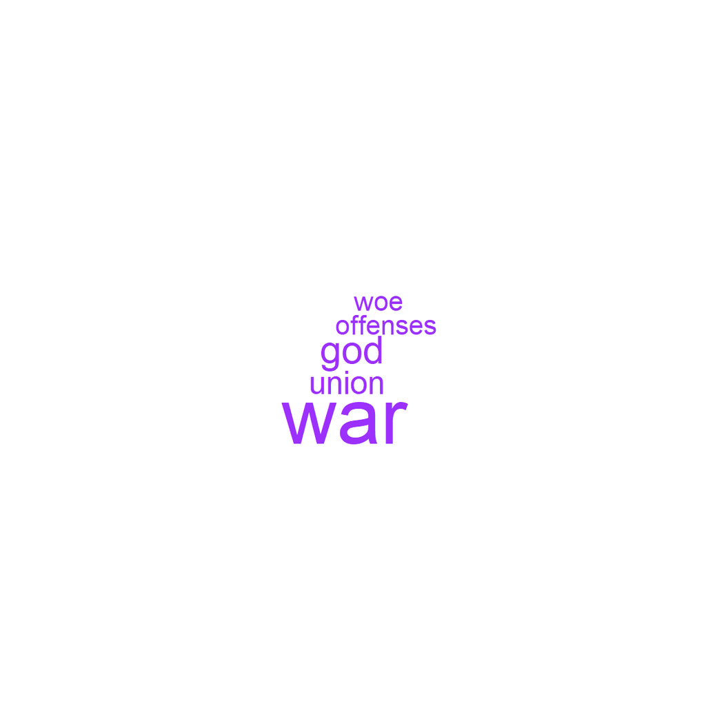

```r
wcd1 <- sentence.list %>% filter(File %in% "AbrahamLincoln", Term == 2) %>% select(File, sentences)
wcd1$sentences <- as.character(wcd1$sentences)
wcd1 <- wcd1 %>% unnest_tokens(word, sentences)
wcd1 <- wcd1 %>%
  anti_join(stop_words, by = "word")
wcd1 %>%
  count(word) %>%
  with(wordcloud(word, n, max.words = 50, color = "purple1"))
```

Comparing to the beginning and end of Great Depression, the money appears more at the end of Great Depression than the beginning.

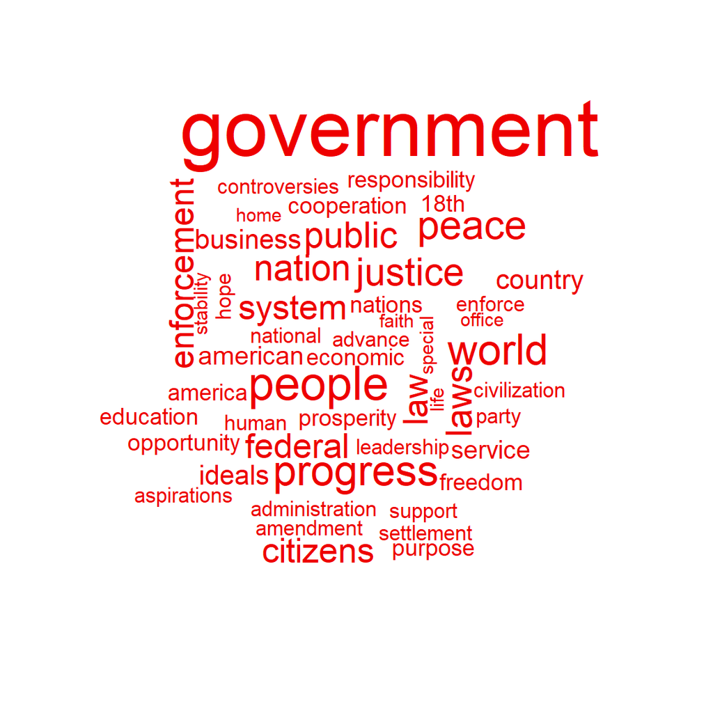

```r
wcd1 <- sentence.list %>% filter(File %in% "HerbertHoover", Term == 1) %>% select(File, sentences)
wcd1$sentences <- as.character(wcd1$sentences)
wcd1 <- wcd1 %>% unnest_tokens(word, sentences)
wcd1 <- wcd1 %>%
  anti_join(stop_words, by = "word")
wcd1 %>%
  count(word) %>%
  with(wordcloud(word, n, max.words = 50, color = "red2"))
```

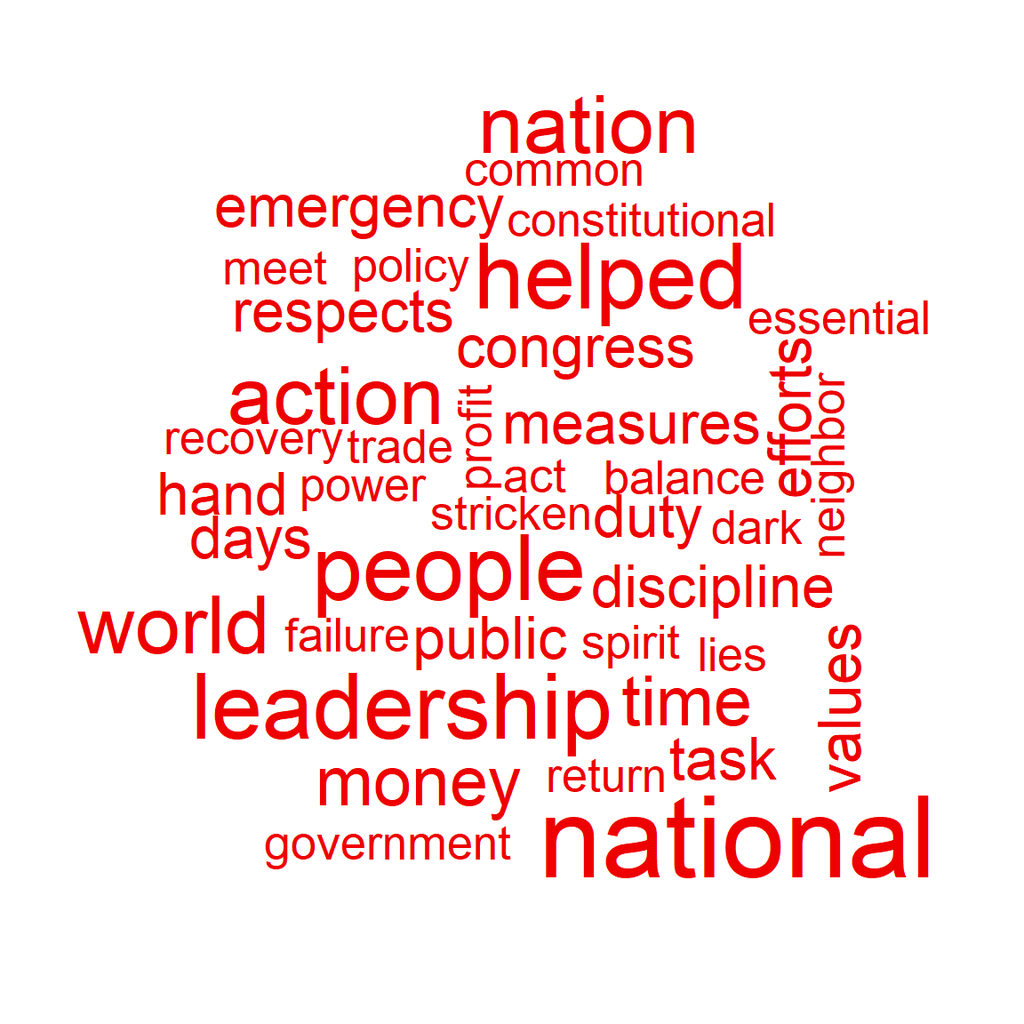

```r
wcd1 <- sentence.list %>% filter(File %in% "FranklinDRoosevelt", Term == 1) %>% select(File, sentences)
wcd1$sentences <- as.character(wcd1$sentences)
wcd1 <- wcd1 %>% unnest_tokens(word, sentences)
wcd1 <- wcd1 %>%
  anti_join(stop_words, by = "word")
wcd1 %>%
  count(word) %>%
  with(wordcloud(word, n, max.words = 50, color = "red2"))
```

So the conclusion is the same with the analysis I get before. Military-related words appear more at the end of war events and economy-related words appear more at the end of economy events.

# Step 6 Calculating the relationship between emotions and topics.

Finally, let me see the realtionship between topic and emotions. I calculate the correlation matrix and get the first three emotions for each topic. It is very funny that the most related emotions to “Legislation” and “Economy” is “Disgust”, “Sadness” and “Anger” and the most related emotions to “Unity” is “Fear”,“Anger” and “Disgust”. I think this tells me that each new presidents were dissatisfied with the former one’s policies and the current situation and they wanted to reform.

```r
correlation.line = c(2,3,12:19,27:34)
correlation.matrix = corpus.list.df[,correlation.line]
correlation <- as.data.frame(cor(correlation.matrix[c(-1,-2)])[1:8,9:16])
corr<- rownames(correlation)[head(apply(correlation,2,order,decreasing=TRUE),3)]
dim(corr) <- c(3,8)
corr <- as.data.frame(corr)
colnames(corr) <- colnames(correlation)
corr
```

```
##   Legislation   Belief Economy   Unity     Military         Hope Equality
## 1     disgust    trust disgust    fear        trust     surprise surprise
## 2     sadness      joy   anger   anger anticipation          joy     fear
## 3       anger surprise sadness disgust          joy anticipation      joy
##        America
## 1          joy
## 2 anticipation
## 3     surprise
```